# Making your research accessible: Data Visualization and Interactive Graphics

Palop and Haaß

15 Juni 2018

## Session 1: Introduction

### About me

**Pau Palop-Garcia**  
*GIGA Hamburg and Freie Universität zu Berlin*

pau.palop@giga-hamburg.de

**Research interests:** migration, political transnationalism, representation

### About you

- Introduce yourself
- Name
- Institution
- Research interests
- Motivation for the course

### Course outline

| Time | Topic |
| --- | --- |
| 10.00-10.30 | Session 1: Introduction and main goals |
| 10.30-12.00 | Session 2: Basics for building an app |
| 12.00-13.00 | *Lunch break* |
| 13.00-14.00 | Session 3: Examples I - Scatter plots- |
| 14.00-14.15 | *Coffee break* |
| 14.15-15.30 | Session 4: Examples II - Interactive maps- |
| 15.30-16.00 | Session 5: Deploying and sharing apps |

### What is an interactive visualization?

[figure not shown]

Source: CC 2015, RStudio, Inc

## Session 2: Basics for building an app

### Main steps for building an app

1. Set main goal for the app
2. Install R Studio and necessary packages (e.g. shiny)
3. Select visualization
4. Prepare the data accordignly
5. Code the app
6. Deploy and share the app

### Some basic examples I

[output not shown]

Shiny applications not supported in static R Markdown documents

### Some basic examples II

Shiny applications not supported in static R Markdown documents

Source: https://shiny.rstudio.com/gallery/kmeans-example.html

### Some basic examples II

Shiny applications not supported in static R Markdown documents

Source: https://shiny.rstudio.com/gallery/telephones-by-region.html

### Preparing the data

- Depends on the app
- General rule: keep it simple

### Structure of a ShinyApp

- **A usser interface (ui):** controls the app layout
- **A server function (server):** contains all the functions needed to build the app
- **A call to the shinyApp function:** creates a shiny app that pairs ui and server

### Building the simplest app

[figure not shown]

Source: CC 2015 RStudio, Inc

### Building the simplest app

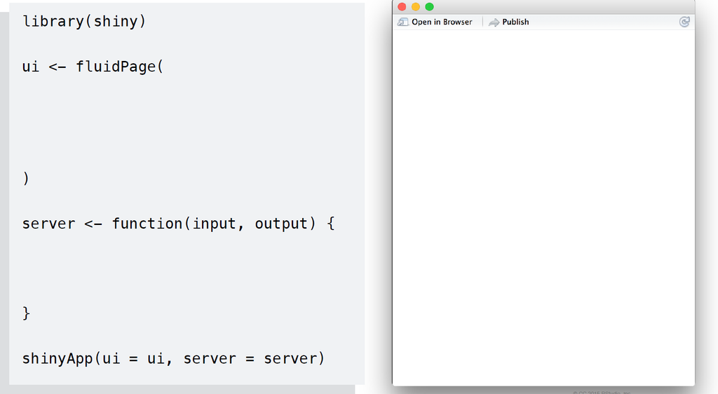

Source: CC 2015 RStudio, Inc

### Building the simplest app

[figure not shown]

Source: CC 2015 RStudio, Inc

### Widgets

- **Definition:** a web element that users can interact with
- A way for users to send messages to the Shiny app
- Widgets are R functions: they required at least two elements to work: a name and a label

### Widgets gallery

[figure not shown]

Source: CC 2015 RStudio, Inc

### Building the simplest app

[figure not shown]

Source: CC 2015 RStudio, Inc

### Building the simplest app

[figure not shown]

Source: CC 2015 RStudio, Inc

### Building the simplest app

[figure not shown]

Source: CC 2015 RStudio, Inc

### Building the simplest app

[figure not shown]

Source: CC 2015 RStudio, Inc

### Reactive outputs

**Reactive outputs respond when users toggles a widget**  
Two main steps: * Add an R object to the user interface * Tell shiny how to build the object in the server function

### Building the simplest app

[figure not shown]

Source: CC 2015 RStudio, Inc

## Session 3: First examples - Scatter plots -

We will use as a baseline the plot that we created in Session 2 of Day 1. Remmember?

```r
library(gapminder)
library(tidyverse)

example_plot <- ggplot(data = gapminder,
                       # the aes() function defines aesthetics
                       aes(x = year,  # x axis
                           y = lifeExp, # y axis
                           color = continent, # map color to continent
                           size = gdpPercap)) + # map the aesthetic 'size' to gdp/pc
  geom_point()
```

## … We can make it interactive

```r
library(gapminder)
library(tidyverse)
library(shiny)

ui <- fluidPage(
  selectInput("continent", "Select continent",
              choices = list("Africa", "Americas", "Asia", "Europe", "Oceania")),
  plotOutput("gpoint")
)


server <- function(input, output) {
  output$gpoint <- renderPlot({
    ggplot(data = subset(gapminder, continent == input$continent, select = c(country:gdpPercap)),
           # the aes() function defines aesthetics
           aes(x = year,  # x axis
               y = lifeExp, # y axis
               color = continent, # map color to continent
               size = gdpPercap)) + # map the aesthetic 'size' to gdp/pc
      geom_point()
  })
}

shinyApp(ui = ui, server = server, options = list(height = 500))
```

Shiny applications not supported in static R Markdown documents

## … Let’s make it a bit more complicated

```r
library(gapminder)
library(tidyverse)
library(shiny)

ui <- fluidPage(
  checkboxGroupInput("continent", "Select continent",
              choices = list("Africa", "Americas", "Asia", "Europe", "Oceania"),
              selected = "Africa"),
  plotOutput("gpoint")
)


server <- function(input, output) {
  output$gpoint <- renderPlot({
    ggplot(data = subset(gapminder, continent %in% input$continent, select = c(country:gdpPercap)),
           # the aes() function defines aesthetics
           aes(x = year,  # x axis
               y = lifeExp, # y axis
               color = continent, # map color to continent
               size = gdpPercap)) + # map the aesthetic 'size' to gdp/pc
      geom_point()
  })
}

shinyApp(ui = ui, server = server, options = list(height = 600))
```

Shiny applications not supported in static R Markdown documents

## … And even a bit more

```r
library(gapminder)
library(tidyverse)
library(shiny)

ui <- fluidPage(
  checkboxGroupInput("continent", "Select continent",
                     choices = list("Africa", "Americas", "Asia", "Europe", "Oceania"),
                     selected = "Africa"),

  sliderInput("slider", label = h3("GDP per capita"), min = 240,
              max = 113600, value = 250),

  plotOutput("gpoint")
)


server <- function(input, output) {
  output$gpoint <- renderPlot({
    ggplot(data = subset(gapminder, continent %in% input$continent &
                           gdpPercap < input$slider , select = c(country:gdpPercap)),
           # the aes() function defines aesthetics
           aes(x = year,  # x axis
               y = lifeExp, # y axis
               color = continent, # map color to continent
               size = gdpPercap)) + # map the aesthetic 'size' to gdp/pc
      geom_point()
  })
}

shinyApp(ui = ui, server = server, options = list(height = 700))
```

Shiny applications not supported in static R Markdown documents

## … Let’s add a sidebar to make it look nicer!

```r
library(gapminder)
library(tidyverse)
library(shiny)

ui <- pageWithSidebar(
  headerPanel("Options"),
  sidebarPanel(
    checkboxGroupInput("continent", "Select continent",
                       choices = list("Africa", "Americas", "Asia", "Europe", "Oceania"),
                       selected = "Africa"),

    sliderInput("slider", label = h3("GDP per capita"), min = 240,
                max = 113600, value = 250)
    ),

  mainPanel(
    plotOutput("gpoint")
  )
)


server <- function(input, output) {
  output$gpoint <- renderPlot({
    ggplot(data = subset(gapminder, continent %in% input$continent &
                           gdpPercap < input$slider , select = c(country:gdpPercap)),
           # the aes() function defines aesthetics
           aes(x = year,  # x axis
               y = lifeExp, # y axis
               color = continent, # map color to continent
               size = gdpPercap)) + # map the aesthetic 'size' to gdp/pc
      geom_point()
  })
}

shinyApp(ui = ui, server = server, options = list(height = 550))
```

Shiny applications not supported in static R Markdown documents

### Exercise 1

Plot an interactive version of the life expectancy in African countries graph using the gapminder data and the static plot developed in Session 2 of Day 1. The interaction should allow users to select the country that they want to highlight. Some tips:

- Which part of the static code should be reactive?
- Which widget/s could be used to create the interaction?
- Create a list of African countries and use it as “choice” in the widget parameters
- Add a *sidebarPanel* and a *mainPanel* to the vizualization

### Solution: Create interaction

```r
library(gapminder)
library(tidyverse)
library(shiny)

gapminder_africa <- gapminder %>%
  # filter only African countries
  filter(continent == "Africa") %>%
  # create a categorical variable that distinguishes
  # between Rwanda and other African countries
  mutate(color_plot = ifelse(country != "Rwanda", # != = "!" + "="
                             "Other African Countries",
                             "Rwanda"))

africa_list <- levels(factor(gapminder_africa$country)) # create a list with African countries

ui <- pageWithSidebar(
  headerPanel("Options"),
  sidebarPanel(
    selectInput("country2", "Select country",
                       choices = africa_list, # Use list of african countries as choices
                       selected = "Algeria") # Select Algeria
  ),

  mainPanel(
    plotOutput("gline")
  )
)


server <- function(input, output) {
  output$gline <- renderPlot({
    gapminder_africa <- gapminder %>%
      # filter only African countries
      filter(continent == "Africa") %>%
      # create a categorical variable that distinguishes
      # between Rwanda and other African countries
      mutate(color_plot = ifelse(country != input$country2, # != = "!" + "="
                                 "Others",
                                 "Selected country"))



      plot <- ggplot(gapminder_africa,
                          aes(x = year,
                              y = lifeExp,
                              group = country,
                              color = color_plot)) +
      geom_line(aes(alpha = color_plot)) +
      scale_alpha_discrete("", range = c(0.5, 1)) +
      scale_color_manual("", values = c("lightgrey", "black")) +

      # add theme
      theme_bw() + # black and white theme
      theme(legend.position = "bottom", # legend position
            panel.grid = element_blank()) # remove grid lines

    print(plot)
  })
}


shinyApp(ui = ui, server = server, options = list(height = 600))
```

Shiny applications not supported in static R Markdown documents

## Session 4: Basic interactive maps

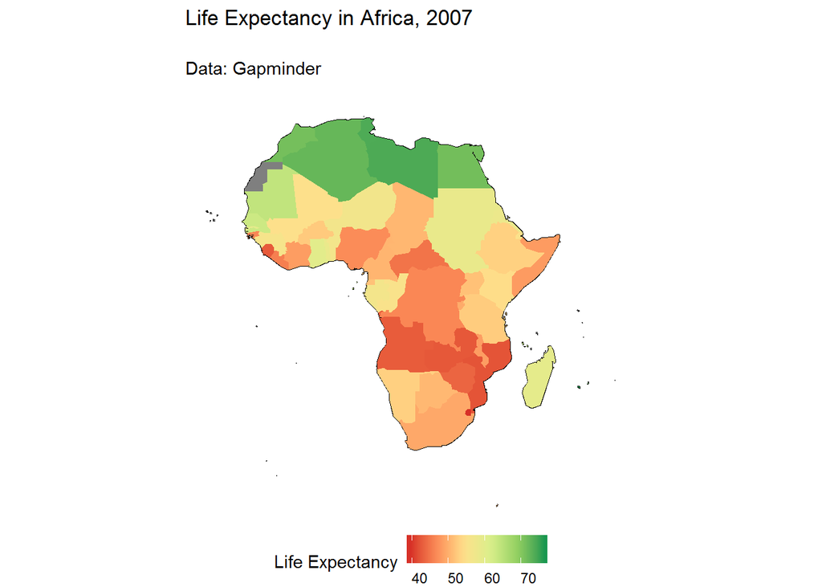

```r
library(countrycode)
library(maptools)
library(ggplot2)
library(tidyverse)
library(gapminder)

world <- readShapeSpatial("./data/shapefiles/TM_WORLD_BORDERS_SIMPL-0.3.shp")

world$continent <- countrycode(world$ISO3,
                               "iso3c", # input format
                               "continent") # output format

africa <- subset(world, continent == "Africa")

# fortify: bring dataset into shape that ggplot can understand
africa_fort <- fortify(africa, # we use the "africa" shapefile from previous slide
                       region = "ISO3") # this becomes "id" in the fortified dataset


# get gapminder data
data("gapminder")

# create country identifier for merging
gapminder$ISO3 <- countrycode(gapminder$country, "country.name", "iso3c")

#only year 2007
gapminder2007 <- gapminder[gapminder$year == 2007, ]

# join in gapminder data
africa_fort <- left_join(africa_fort,
                         gapminder2007,
                         by = c("id" = "ISO3"))


africa_map <- ggplot() +
  geom_path(data = africa_fort,
            aes(x = long, y = lat,
                group = group),
            color = "black")  +
  geom_map(data = africa_fort,
           aes(map_id = id,
               fill = lifeExp),
           map = africa_fort) +

  # appearance
  labs(title = "Life Expectancy in Africa, 2007\n",
       subtitle = "Data: Gapminder\n") +
  scale_fill_distiller("Life Expectancy",
                       palette = "RdYlGn",
                       direction = 1) +
  coord_equal() +
  theme_void() +
  theme(panel.grid = element_blank(),
        legend.position = "bottom",
        legend.text.align = 0)

plot(africa_map)
```

### Creating an interactive map

```r
library(countrycode)
library(maptools)
library(ggplot2)
library(tidyverse)
library(gapminder)

ui <- fluidPage(
  radioButtons("variable", "Select variable",
                     choices = list("lifeExp", "pop", "gdpPercap"),
               selected = "lifeExp"),

  plotOutput("gmap")
)


server <- function(input, output) {
  output$gmap <- renderPlot({
    world <- readShapeSpatial("./data/shapefiles/TM_WORLD_BORDERS_SIMPL-0.3.shp")

    world$continent <- countrycode(world$ISO3,
                                   "iso3c", # input format
                                   "continent") # output format

    africa <- subset(world, continent == "Africa")

    # fortify: bring dataset into shape that ggplot can understand
    africa_fort <- fortify(africa, # we use the "africa" shapefile from previous slide
                           region = "ISO3") # this becomes "id" in the fortified dataset


    # get gapminder data
    data("gapminder")

    # create country identifier for merging
    gapminder$ISO3 <- countrycode(gapminder$country, "country.name", "iso3c")

    #only year 2007
    gapminder2007 <- gapminder[gapminder$year == 2007, ]

    # join in gapminder data
    africa_fort <- left_join(africa_fort,
                             gapminder2007,
                             by = c("id" = "ISO3"))

    #Create reactive variable
    africa_fort$var <- africa_fort[,input$variable]

    africa_map <- ggplot() +
      geom_path(data = africa_fort,
                aes(x = long, y = lat,
                    group = group),
                color = "black")  +
      geom_map(data = africa_fort,
               aes(map_id = id,
                   fill = var),
               map = africa_fort) +

      # appearance
      labs(title = "",
           subtitle = "") +
      scale_fill_distiller("",
                           palette = "RdYlGn",
                           direction = 1) +
      coord_equal() +
      theme_void() +
      theme(panel.grid = element_blank(),
            legend.position = "bottom",
            legend.text.align = 0)

    plot(africa_map)
  })
}

shinyApp(ui = ui, server = server, options = list(height = 700))
```

Shiny applications not supported in static R Markdown documents

### Exercise 2

Plot an interactive vizualization in which not only the user can select the variable AND the year that should be plotted. The app layout should include also a sidebar and a mainpanel. Steps:

1. Create a ui with a sidebar and a mainpanel
2. Create two widgets in the ui (one for the variable and one for the years)
3. Create a reactive expression to subset the data: (1) select year and (2) select variable
4. Create map in server
5. Call shiny fuction

### Solution

```r
ui <- pageWithSidebar(
  headerPanel("Select options"),
  sidebarPanel(
    radioButtons("variable", "Select variable",
                 choices = list("Life expectancy" = "lifeExp", "Population" = "pop",
                                "GDP per capita" = "gdpPercap"),
                 selected = "lifeExp"),
    radioButtons("year", label = "Select year",
                 choices = list("1952", "1957", "1962", "1967",
                                "1972", "1977", "1982", "1987",
                                "1992", "1997", "2002", "2007"),
                 selected = "1952")
  ),
  mainPanel(
    plotOutput("gmap")
  )
)



server <- function(input, output) {
  output$gmap <- renderPlot({
    world <- readShapeSpatial("./data/shapefiles/TM_WORLD_BORDERS_SIMPL-0.3.shp")

    world$continent <- countrycode(world$ISO3,
                                   "iso3c", # input format
                                   "continent") # output format

    africa <- subset(world, continent == "Africa")

    # fortify: bring dataset into shape that ggplot can understand
    africa_fort <- fortify(africa, # we use the "africa" shapefile from previous slide
                           region = "ISO3") # this becomes "id" in the fortified dataset


    # get gapminder data
    data("gapminder")

    # create country identifier for merging
    gapminder$ISO3 <- countrycode(gapminder$country, "country.name", "iso3c")

    #only year
    gapminder_year <- gapminder[gapminder$year == input$year, ]

    # join in gapminder data
    africa_fort <- left_join(africa_fort,
                             gapminder_year,
                             by = c("id" = "ISO3"))

    #Create reactive variable
    africa_fort$var <- africa_fort[,input$variable]

    africa_map <- ggplot() +
      geom_path(data = africa_fort,
                aes(x = long, y = lat,
                    group = group),
                color = "gray")  +
      geom_map(data = africa_fort,
               aes(map_id = id,
                   fill = var),
               map = africa_fort) +

      # appearance
      labs(title = "",
           subtitle = "") +
      scale_fill_distiller("",
                           palette = "RdYlGn",
                           direction = 1) +
      coord_equal() +
      theme_void() +
      theme(panel.grid = element_blank(),
            legend.position = "bottom",
            legend.text.align = 0)

    plot(africa_map)
  })
}

shinyApp(ui = ui, server = server, options = list(height = 700))
```

Shiny applications not supported in static R Markdown documents

## Session 5: Deploying and sharing apps

### Main steps for building an app

1. Set main goal for the app
2. Install R Studio and necessary packages (e.g. shiny)
3. Select visualization
4. Prepare the data accordignly
5. Code the app **6. Deploy and share the app**

### Deploying and sharing the app

Every shiny app is maintained by a computer running R  
How to save it:

- app.R
- datasets, images, css, helper scripts, etc.

### Deploying and sharing the app

Using shinyapps.io:

- Free
- Secure
- Scalable

### Sharing in your website via iframe

[figure not shown]

GIGA 2018

### Other sharing options

- R Markdown
- R Shiny presentations